# Geospatial Analysis

Prediction and Understanding of the relevant variables

Ludovico Maria Valenti

2023-01-15

```r
install.packages(c('sf', 'tmap', 'spdep', 'spatialreg', 'sp', 'olsrr',
                   'ramdomForest', 'randomForestExplainer', 'tree', 'DALEX', 'shapper'))
reticulate::py_install(c('pandas', 'numpy', 'shap'))
```

```
## + '/home/link92/.local/share/r-miniconda/bin/conda' 'install' '--yes' '--prefix' '/home/link92/.local/share/r-miniconda/envs/r-reticulate' '-c' 'conda-forge' 'pandas' 'numpy' 'shap'
```

```r
library(sf); library(tmap); library(spdep); library(spatialreg); library(sp);
library(olsrr); library(randomForest); library(randomForestExplainer);
library(tree); library(gbm); library(shapper); library(DALEX); library(e1071)
```

I’ll begin by loading the hexagons pre-computed hexagons of the city using the `h3` package. For the further analyses I will use a spatial resolution of $8$:

```r
setwd('/home/link92/Downloads/R session/project')

# load the hexagons @ resolution 8
tv_hexagons <- st_read('rel_frequencies_res8/basemap_8.shp')
```

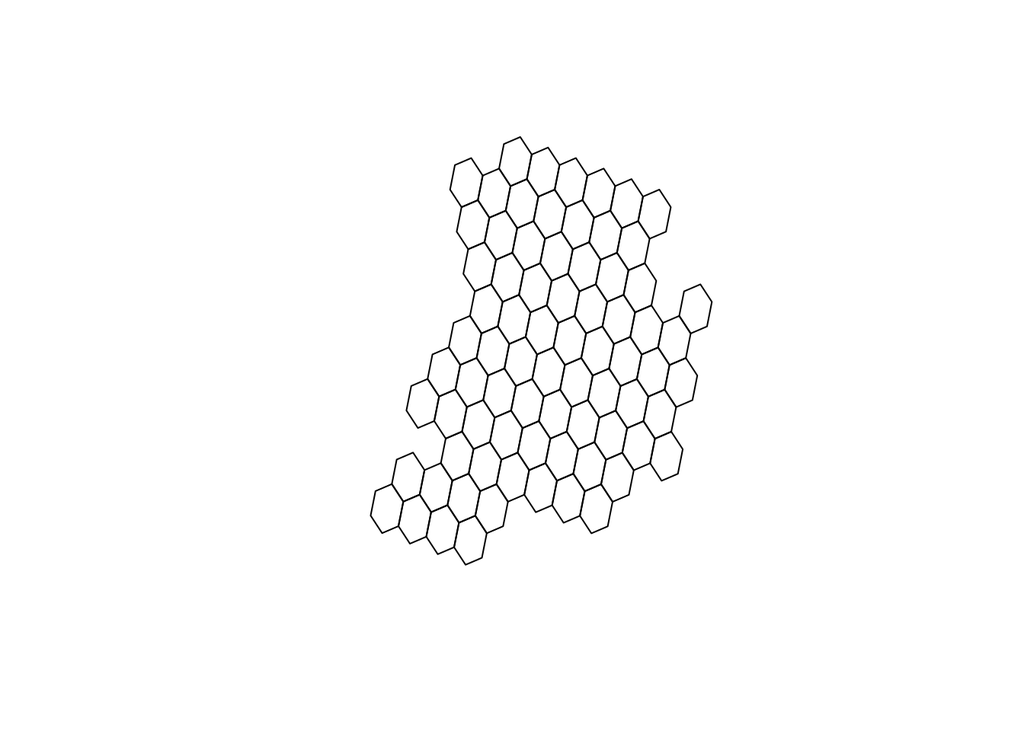

```r
plot(st_geometry(tv_hexagons))
```

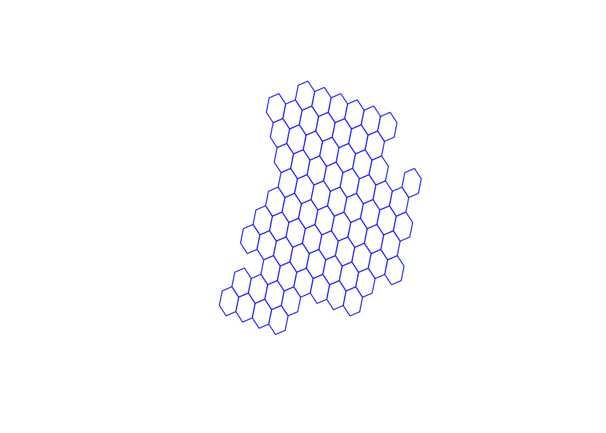

```r
# create contiguity-based neighbors starting from the hexagons
contnb_q <- poly2nb(tv_hexagons, queen=T)
plot(st_geometry(tv_hexagons), border='blue')
```

```r
# create row-standardized weight matrix
W <- nb2listw(contnb_q, style='W')
```

The data has been divided into `train` and `test` based on the year:

- the train set (`df_train`) includes data from 2005 to 2017
- the test set (`df_test`) includes data from 2018 to 2022

```r
df_train <- read.csv(file='rel_frequencies_res8/hexagon_dataframe_rel_freq_train_res8.csv')
df_test <- read.csv(file='rel_frequencies_res8/hexagon_dataframe_rel_freq_test_res8.csv')
```

Since the hexagons in `df_train` and `df_test` do not fully cover the basemap (i.e. some hexagons have no accidents), I’ll reconstruct both dataframes based on the `col_hex_id` and fill in any empty hexagons with zeros. This will ensure that the weight matrix remains consistent.

```r
new_df_train <- data.frame(matrix(0, nrow=length(W$weights), ncol=length(colnames(df_train))))
colnames(new_df_train) <- colnames(df_train)

new_df_test <- data.frame(matrix(0, nrow=length(W$weights), ncol=length(colnames(df_test))))
colnames(new_df_test) <- colnames(df_test)

# loop hexagons and add the corresponding rows to the new_df
for (i in seq(1, length(tv_hexagons$col_hex_8))){
  curr_hex <- tv_hexagons$col_hex_8[i]

  if (curr_hex %in% df_train$col_hex_8){
    row_to_ins <- df_train[df_train$col_hex_8 == curr_hex, ]
    new_df_train[i, ] <- row_to_ins
  }

  if (curr_hex %in% df_test$col_hex_8){
    row_to_ins <- df_test[df_test$col_hex_8 == curr_hex, ]
    new_df_test[i, ] <- row_to_ins
  }
}


# remove also the hexagon_id information, and some of the variables that do not
# make any sense to include in order to predict the y or that cause trouble while training the following models

new_df_train <- subset(new_df_train, select=-c(col_hex_8, Feriti, Morti, elettrici, ghiacciato, Strada.pavimentata.dissestata, Altra.strada, Altro.tempo, Altra.pavimentazione))
new_df_test <- subset(new_df_test, select=-c(col_hex_8, Feriti, Morti, elettrici, ghiacciato, Strada.pavimentata.dissestata, Altra.strada, Altro.tempo, Altra.pavimentazione))

head(new_df_train)
```

```
##    hour.0.7 hour.8.15 hour.16.23 end_of_week Contro.ostacoli
## 1 0.0000000 0.0000000  0.0000000   0.0000000               0
## 2 0.1052632 0.6842105  0.2105263   0.1578947               0
## 3 0.0000000 1.0000000  0.0000000   0.0000000               0
## 4 0.0000000 0.0000000  1.0000000   0.5000000               0
## 5 0.0000000 0.0000000  0.0000000   0.0000000               0
## 6 0.5000000 0.0000000  0.5000000   0.5000000               0
##   Contro.veicoli.fermi    Da.solo Investimento Scontro.fra.veicoli.in.movimento
## 1                    0 0.00000000            0                        0.0000000
## 2                    0 0.05263158            0                        0.5789474
## 3                    0 1.00000000            0                        0.0000000
## 4                    0 0.00000000            0                        1.0000000
## 5                    0 0.00000000            0                        0.0000000
## 6                    0 1.00000000            0                        0.0000000
##   Tamponamento Altro.tipo.di.strada      Curva  Incrocio Intersezione
```

[output cut: 41 more lines]

```r
head(new_df_test)
```

```
##   hour.0.7 hour.8.15 hour.16.23 end_of_week Contro.ostacoli
## 1        0         0          0           0               0
## 2        0         0          0           0               0
## 3        0         1          0           0               0
## 4        0         0          0           0               0
## 5        0         1          0           0               0
## 6        0         0          0           0               0
##   Contro.veicoli.fermi Da.solo Investimento Scontro.fra.veicoli.in.movimento
## 1                    0       0            0                                0
## 2                    0       0            0                                0
## 3                    0       0            0                                1
## 4                    0       0            0                                0
## 5                    0       0            0                                1
## 6                    0       0            0                                0
##   Tamponamento Altro.tipo.di.strada Curva Incrocio Intersezione Rettilineo
```

[output cut: 34 more lines]

To start, I’ll fit a linear model first:

```r
OLSmodel <- lm(y ~ ., data=new_df_train)
summary(OLSmodel)
```

```
##
## Call:
## lm(formula = y ~ ., data = new_df_train)
##
## Residuals:
##     Min      1Q  Median      3Q     Max
## -122.01  -17.48    0.00   16.87  208.08
##
## Coefficients: (3 not defined because of singularities)
##                                    Estimate Std. Error t value Pr(>|t|)
## (Intercept)                      -3.254e-12  2.467e+01   0.000  1.00000
## hour.0.7                         -3.676e+02  2.830e+03  -0.130  0.89737
## hour.8.15                        -5.425e+02  2.910e+03  -0.186  0.85315
## hour.16.23                       -2.024e+02  2.933e+03  -0.069  0.94538
## end_of_week                       2.814e+00  1.079e+02   0.026  0.97934
## Contro.ostacoli                  -1.402e+02  2.735e+02  -0.512  0.61145
## Contro.veicoli.fermi              9.473e+02  5.733e+02   1.652  0.10718
## Da.solo                          -3.858e+02  2.921e+02  -1.321  0.19484
## Investimento                     -1.065e+02  4.298e+02  -0.248  0.80568
## Scontro.fra.veicoli.in.movimento -2.475e+02  1.733e+02  -1.428  0.16184
## Tamponamento                             NA         NA      NA       NA
## Altro.tipo.di.strada             -2.617e+02  5.928e+02  -0.441  0.66154
## Curva                            -1.900e+02  2.370e+02  -0.801  0.42814
## Incrocio                         -2.761e+01  2.245e+02  -0.123  0.90282
## Intersezione                      5.652e+02  4.004e+02   1.412  0.16667
## Rettilineo                       -2.055e+02  2.037e+02  -1.009  0.31964
## Rotatoria                                NA         NA      NA       NA
## asciutto                          3.481e+02  7.992e+02   0.436  0.66577
## bagnato                           4.812e+02  8.496e+02   0.566  0.57461
## viscido                          -1.607e+03  2.791e+03  -0.576  0.56837
## Asfaltata                         1.804e+03  2.350e+03   0.768  0.44756
## In.cubetti.di.porfido             1.895e+03  2.394e+03   0.792  0.43370
## auto                              2.019e+02  5.431e+02   0.372  0.71225
## moto                              1.355e+02  5.116e+02   0.265  0.79256
## bus                               1.380e+03  7.531e+02   1.832  0.07520 .
## camion                            2.989e+02  6.296e+02   0.475  0.63778
## lavoro                            1.033e+03  6.381e+02   1.620  0.11403
## bici                              7.119e+02  5.758e+02   1.236  0.22430
## altro                             1.879e+03  1.486e+03   1.264  0.21443
## Nebbia                           -1.792e+03  1.855e+03  -0.966  0.34029
## Nuvoloso                         -1.429e+03  1.643e+03  -0.870  0.39030
## Pioggia                          -1.338e+03  1.582e+03  -0.845  0.40347
## Sereno                           -1.494e+03  1.636e+03  -0.913  0.36707
## Provinciale                       3.753e+01  1.126e+03   0.033  0.97360
## Regionale                        -1.448e+02  1.031e+03  -0.140  0.88908
## Statale                           4.353e+01  1.136e+03   0.038  0.96965
## Urbana                            1.639e+02  1.103e+03   0.149  0.88269
## Traffico.Intenso                  5.042e+02  1.825e+02   2.763  0.00897 **
## Traffico.Normale                  7.631e+01  1.253e+02   0.609  0.54647
## Traffico.Scarso                          NA         NA      NA       NA
## media.veicoli.coinvolti          -4.196e+02  5.606e+02  -0.749  0.45901
## luce                              3.845e+02  2.180e+02   1.764  0.08627 .
## centro.abitato                   -1.363e+02  3.675e+02  -0.371  0.71282
## ---
## Signif. codes:  0 '***' 0.001 '**' 0.01 '*' 0.05 '.' 0.1 ' ' 1
##
## Residual standard error: 74 on 36 degrees of freedom
## Multiple R-squared:  0.811,  Adjusted R-squared:  0.6063
## F-statistic: 3.962 on 39 and 36 DF,  p-value: 3.194e-05
```

Some of the coefficient were not computed, this is because the correspondent variables are `Aliases` (i.e., correlated to one another). As a solution, I’ll use a `stepwise` method in order to keep the relevant variables only, while also removing the collinear ones.

```r
# forward + backward
stp <- ols_step_both_p(OLSmodel)
```

According to the `stepwise` method, the variables listed below are the most significant in determining the number of accidents:

```r
stp$predictors
```

```
## [1] "bici"                  "Intersezione"          "In.cubetti.di.porfido"
## [4] "Nebbia"                "Traffico.Intenso"      "Contro.veicoli.fermi"
## [7] "Rettilineo"            "Investimento"          "bus"
```

Let’s see a summary of the selected model:

```r
summary(stp$model)
```

```
##
## Call:
## lm(formula = paste(response, "~", paste(preds, collapse = " + ")),
##     data = l)
##
## Residuals:
##      Min       1Q   Median       3Q      Max
## -130.845  -33.800   -5.131   24.684  244.777
##
## Coefficients:
##                       Estimate Std. Error t value Pr(>|t|)
## (Intercept)              5.131     16.247   0.316 0.753170
## bici                   356.871     84.882   4.204 8.05e-05 ***
## Intersezione           940.466    253.810   3.705 0.000434 ***
## In.cubetti.di.porfido  504.401    267.851   1.883 0.064089 .
## Nebbia                -988.845    393.739  -2.511 0.014480 *
## Traffico.Intenso       233.496     82.887   2.817 0.006387 **
## Contro.veicoli.fermi   868.591    371.409   2.339 0.022393 *
## Rettilineo            -106.007     35.470  -2.989 0.003933 **
## Investimento           353.350    156.675   2.255 0.027436 *
## bus                    653.545    381.648   1.712 0.091513 .
## ---
## Signif. codes:  0 '***' 0.001 '**' 0.01 '*' 0.05 '.' 0.1 ' ' 1
##
## Residual standard error: 66.59 on 66 degrees of freedom
## Multiple R-squared:  0.7194, Adjusted R-squared:  0.6812
## F-statistic:  18.8 on 9 and 66 DF,  p-value: 4.48e-15
```

All the variables, except for `bus` and `In.cubetti.di.porfido` are significant in predicting the number of accidents In particular, it is possible to note that:

- for each unit increase in the variables `Nebbia` and `Rettilineo`, there is a decrease of $988$ and $106$ in the number of accidents, respectively. However, it is counterintuitive that an increase in the accidents under fog conditions would lead to a decrease in the number of predicted accidents.
- for each unit increase in the variables `Intersezione`, `Contro.veicoli.fermi`, `bici` and `Investimento`, there is an increase in the number of predicted accidents. This makes sense as intersections are typically unregulated (i.e. no traffic lights) and high traffic conditions are known to lead to a higher likelihood of accidents. For what concerns the involvement of bikes and pedestrians, it could be that higher proportions of their involvement is the result of a general overcrowding (of both vehicles and people) in those areas.

Does it make any sense to account for spatial information while fitting a model?

```r
OLSmodel <- lm(y ~ bici + Intersezione + In.cubetti.di.porfido + Nebbia + Traffico.Intenso +
                   Contro.veicoli.fermi + Rettilineo + Investimento + bus, data=new_df_train)

OLSlmtests <- lm.LMtests(OLSmodel, listw=W, test=c("LMerr", "LMlag", "RLMerr", "RLMlag"))
summary(OLSlmtests)
```

```
##  Lagrange multiplier diagnostics for spatial dependence
## data:
## model: lm(formula = y ~ bici + Intersezione + In.cubetti.di.porfido +
## Nebbia + Traffico.Intenso + Contro.veicoli.fermi + Rettilineo +
## Investimento + bus, data = new_df_train)
## weights: W
##
##        statistic parameter p.value
## LMerr   0.265998         1  0.6060
## LMlag   0.030318         1  0.8618
## RLMerr  0.920708         1  0.3373
## RLMlag  0.685028         1  0.4079
```

According to the results of the `LM` diagnostics, it seems that there is no significant spatial dependence. As a result, a linear model is not any statistically different from a `Spatial Error Model` or a `Spatial Lag Model`. We can still try to fit these models, but I expect the parameter `Rho` to be non significant:

```r
SDM <- lagsarlm(y ~ Intersezione + In.cubetti.di.porfido + Nebbia + Traffico.Intenso +
                   Contro.veicoli.fermi + Rettilineo + Investimento + bus, data=new_df_train,
                   listw=W, type='mixed')

summary(SDM)
```

```
##
## Call:lagsarlm(formula = y ~ Intersezione + In.cubetti.di.porfido +
##     Nebbia + Traffico.Intenso + Contro.veicoli.fermi + Rettilineo +
##     Investimento + bus, data = new_df_train, listw = W, type = "mixed")
##
## Residuals:
##       Min        1Q    Median        3Q       Max
## -148.4639  -33.2012   -9.3307   23.9570  248.6628
##
## Type: mixed
## Coefficients: (asymptotic standard errors)
##                            Estimate Std. Error z value  Pr(>|z|)
## (Intercept)                  17.796     55.806  0.3189 0.7498075
## Intersezione               1154.258    245.261  4.7062 2.523e-06
## In.cubetti.di.porfido       784.534    278.749  2.8145 0.0048856
## Nebbia                     -250.649    410.792 -0.6102 0.5417551
## Traffico.Intenso            312.756     86.540  3.6140 0.0003015
## Contro.veicoli.fermi        764.059    391.289  1.9527 0.0508588
## Rettilineo                  -86.207     39.000 -2.2104 0.0270754
## Investimento                618.224    162.153  3.8126 0.0001375
## bus                         473.682    393.137  1.2049 0.2282507
## lag.Intersezione            457.314    532.152  0.8594 0.3901385
## lag.In.cubetti.di.porfido  2329.281    993.532  2.3444 0.0190554
## lag.Nebbia                 -897.472    654.788 -1.3706 0.1704902
## lag.Traffico.Intenso        404.751    231.148  1.7510 0.0799380
## lag.Contro.veicoli.fermi  -1310.628   1142.927 -1.1467 0.2514937
## lag.Rettilineo              -66.643    100.423 -0.6636 0.5069334
## lag.Investimento            -29.507    348.891 -0.0846 0.9325994
## lag.bus                     120.572    921.022  0.1309 0.8958453
##
## Rho: -0.14271, LR test value: 0.55374, p-value: 0.45679
## Asymptotic standard error: 0.17455
##     z-value: -0.81756, p-value: 0.41361
## Wald statistic: 0.66841, p-value: 0.41361
##
## Log likelihood: -425.2794 for mixed model
## ML residual variance (sigma squared): 4228.2, (sigma: 65.024)
## Number of observations: 76
## Number of parameters estimated: 19
## AIC: 888.56, (AIC for lm: 887.11)
## LM test for residual autocorrelation
## test value: 0.78215, p-value: 0.37649
```

```r
SEM <- errorsarlm(y ~ Intersezione + In.cubetti.di.porfido + Nebbia + Traffico.Intenso +
                   Contro.veicoli.fermi + Rettilineo + Investimento + bus, data=new_df_train,
                   listw=W)

summary(SEM)
```

```
##
## Call:errorsarlm(formula = y ~ Intersezione + In.cubetti.di.porfido +
##     Nebbia + Traffico.Intenso + Contro.veicoli.fermi + Rettilineo +
##     Investimento + bus, data = new_df_train, listw = W)
##
## Residuals:
##      Min       1Q   Median       3Q      Max
## -167.345  -28.342  -11.255   21.964  262.690
##
## Type: error
## Coefficients: (asymptotic standard errors)
##                       Estimate Std. Error z value  Pr(>|z|)
## (Intercept)             24.573     16.148  1.5217 0.1280833
## Intersezione          1222.400    254.122  4.8103 1.507e-06
## In.cubetti.di.porfido  707.285    278.852  2.5364 0.0111995
## Nebbia                -519.820    391.089 -1.3292 0.1837947
## Traffico.Intenso       290.044     86.689  3.3458 0.0008205
## Contro.veicoli.fermi   889.980    386.501  2.3027 0.0212980
## Rettilineo             -97.796     37.241 -2.6260 0.0086383
## Investimento           574.281    152.045  3.7770 0.0001587
## bus                    567.083    399.292  1.4202 0.1555435
##
## Lambda: -0.11065, LR test value: 0.27837, p-value: 0.59777
## Asymptotic standard error: 0.17747
##     z-value: -0.62348, p-value: 0.53297
## Wald statistic: 0.38872, p-value: 0.53297
##
## Log likelihood: -430.4498 for error model
## ML residual variance (sigma squared): 4852.4, (sigma: 69.659)
## Number of observations: 76
## Number of parameters estimated: 11
## AIC: 882.9, (AIC for lm: 881.18)
```

Now I’ll fit a `Decision Tree`:

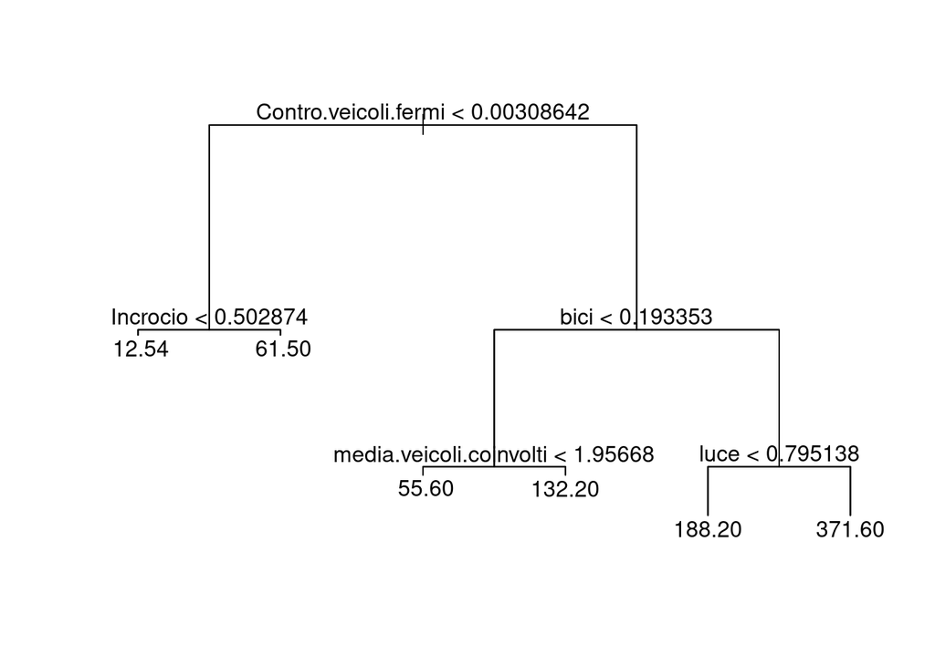

```r
full_tr <- tree(y ~ ., data=new_df_train)

plot(full_tr)
text(full_tr, pretty=0)
```

It is important to stress on the fact that the data was re-processed into relative frequencies, which means that each group of variables is interconnected. For example, the variable `bici` represents the proportion of accidents that involved bikes **relatively** to all the accidents that involved the other vehicles.

Now I’ll check if it is possible to prune the tree:

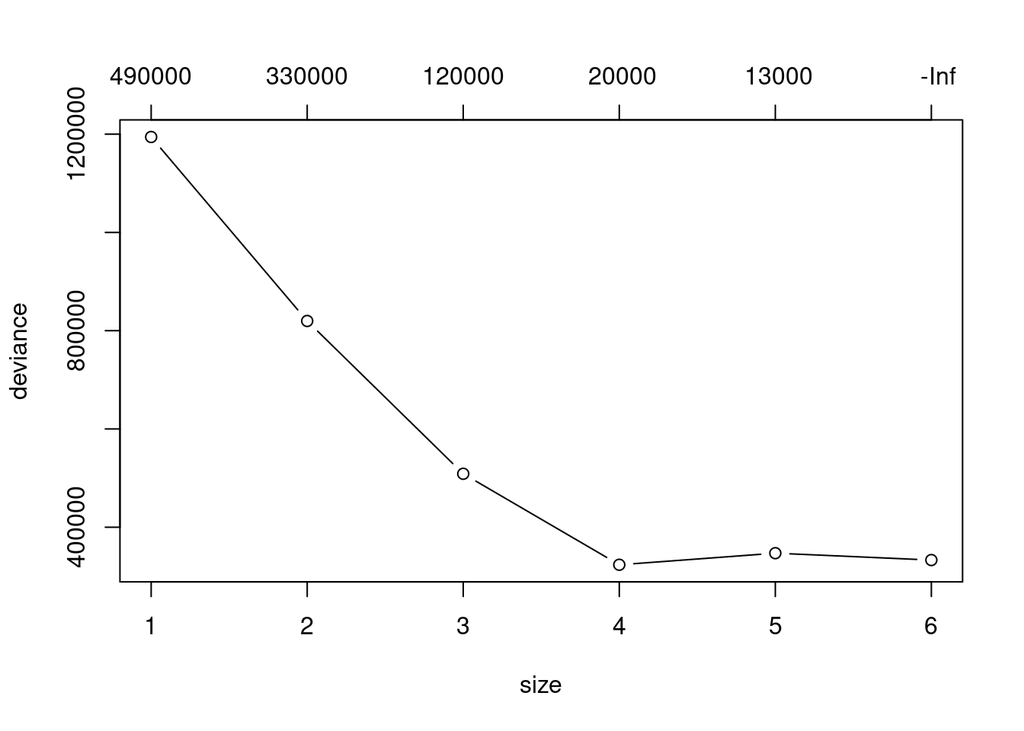

```r
cv_tree <- cv.tree(full_tr, K=nrow(new_df_train)-1)

plot(cv_tree, type='b')
```

```r
best_cut <- data.frame(cv_tree$size, cv_tree$dev)

best_cut <- best_cut[order(cv_tree$dev), ][1, 1]
```

We can prune it at $4$ leaves:

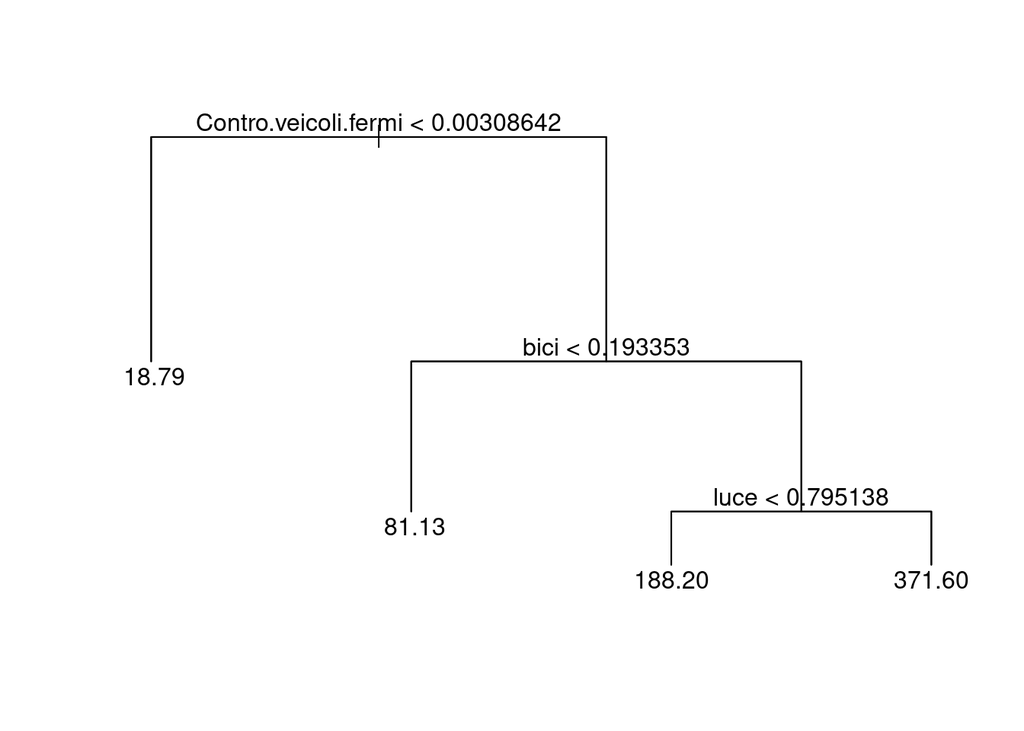

```r
pruned_t <- prune.tree(full_tr, best=best_cut)
plot(pruned_t)
text(pruned_t, pretty=0)
```

Let us see if the models hold while predicting new/unseen observations:

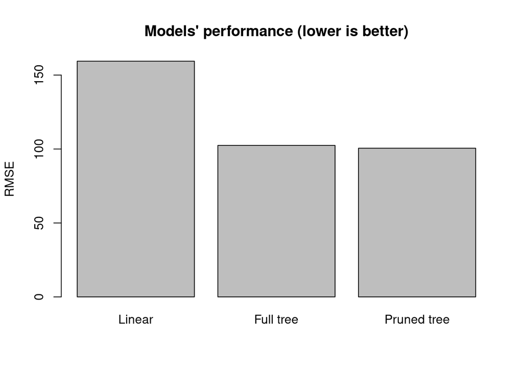

```r
lin_preds <- predict(OLSmodel, newdata=new_df_test)
lin_preds <- ifelse(lin_preds < 0, 0, lin_preds)

full_preds <- predict(full_tr, newdata=new_df_test)

pruned_preds <- predict(pruned_t, newdata=new_df_test)

#RMSE Full Tree
r_full <- sqrt(sum((full_preds - new_df_test$y)^2) / length(new_df_test$y))

# RMSE Pruned Tree
r_pruned <- sqrt(sum((pruned_preds - new_df_test$y)^2) / length(new_df_test$y))

# RMSE Linear Model
r_lin <- sqrt(sum((lin_preds - new_df_test$y)^2) / length(new_df_test$y))

barplot(names=c('Linear', 'Full tree', 'Pruned tree'), c(r_lin, r_full, r_pruned),
        main="Models' performance (lower is better)", ylab='RMSE', ylim=c(0, r_lin))
```

```r
paste0(c('Linear model', r_lin), sep=':')
```

```
## [1] "Linear model:"     "159.412435758482:"
```

```r
paste0(c('Full Tree', r_full), sep=':')
```

```
## [1] "Full Tree:"        "102.459875971272:"
```

```r
paste0(c('Pruned Tree', r_pruned), sep=':')
```

```
## [1] "Pruned Tree:"      "100.550268562651:"
```

With respect to a `linear model`, both the full and the pruned trees are definitely better. The pruned one is, as expected, pretty much the same as the full one. On average, the `pruned tree` estimates the number of accidents with an error of 100 per area.

Now I’ll try to fit also a Random Forest model. First I’ll fit multiple `Random Forests`, so to understand what is the best number of (randomly sampled) variables to account for:

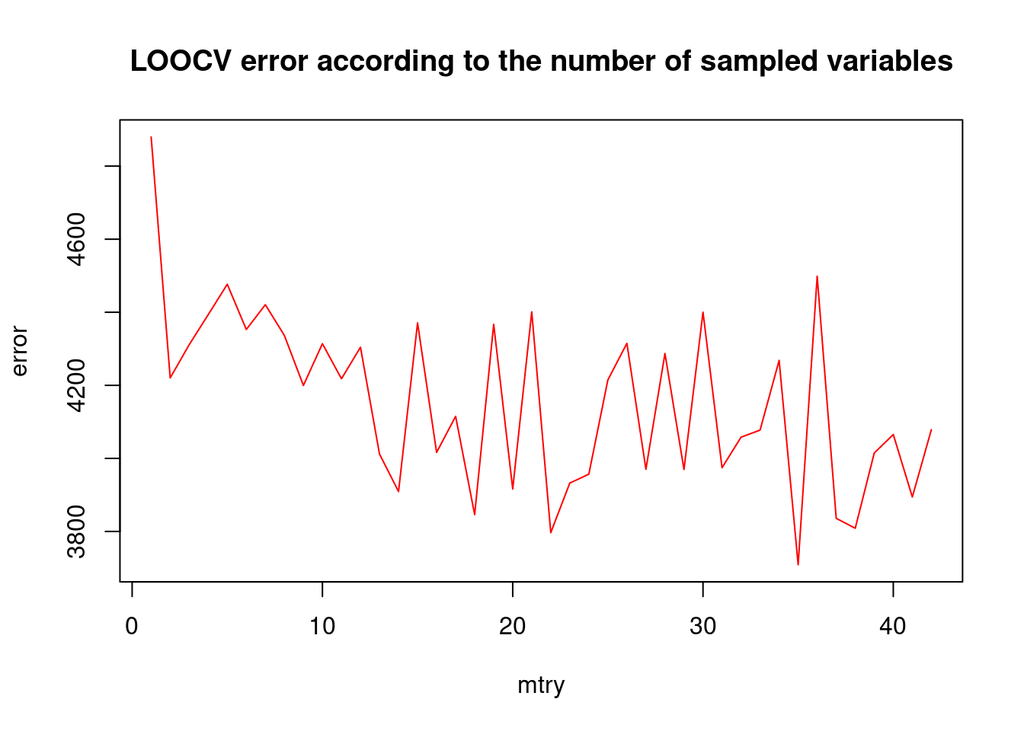

```r
set.seed(42)
res <- matrix(nrow=ncol(new_df_train) - 1, ncol=1)
m <- 1:(ncol(new_df_train) - 1)

for (i in m){
  rf = randomForest(y ~ ., data=new_df_train, mtry=i, K=nrow(new_df_train)-1, OOB_score=F)
  res[i, 1] <- mean(rf$mse)
}

res <- data.frame(CV=res[, 1])

plot(x=seq(1, nrow(res)), y=res$CV, type='l', col='red', xlab='mtry', ylab='error', main='LOOCV error according to the number of sampled variables')
```

The number of variables that grants a lower error is $35$, but $22$ grants an equivalently low error:

```r
set.seed(42)
rf <- randomForest(y ~ ., localImp=T, data=new_df_train, mtry=22)
```

Random Forest is not very friendly with interpretability, nonetheless, I’ll squeeze information out as much as it is possible.

First we look at the `distribution of minimal depth`. This plot allows us to see at - as the name says - the distribution of minimal depth among the trees. The vertical bar indicates the mean of the distribution, the scale of X goes from zero to the maximum number of trees in which the variable was used for splitting. This plot allows us to see which variables were split the closest to the root of each tree. When this is low, it means that a lot of variables are divided into groups based on that variable (i.e., that variable is important in explaining the number of accidents):

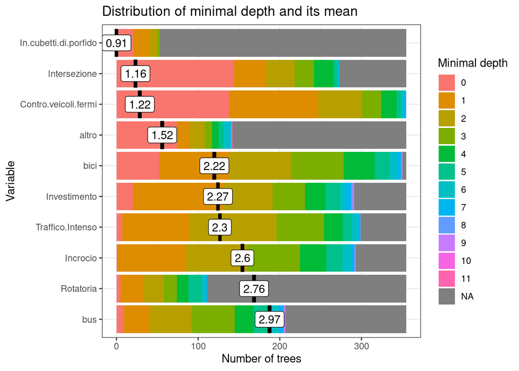

```r
plot_min_depth_distribution(rf, mean_sample='relevant_trees')
```

Half of the times `Rotatoria` is not used to determine the number of accidents, so, it seems that knowing the proportions of `Incrocio` and `Intersezione` is more relevant.

Now I’ll look into the `Multi-way importance plot`. It shows the relation between three relevant measures:

- mean depth of first split on the variable
- number of trees in which the root is split on the variable
- total number of nodes in the forest that split on that variable

Looking at this plot from top-left to bottom-right we can understand the most important variables:

The higher a variable it is, the most times it is chosen as a root node; the most it is on the left, the lower it is in the tree.

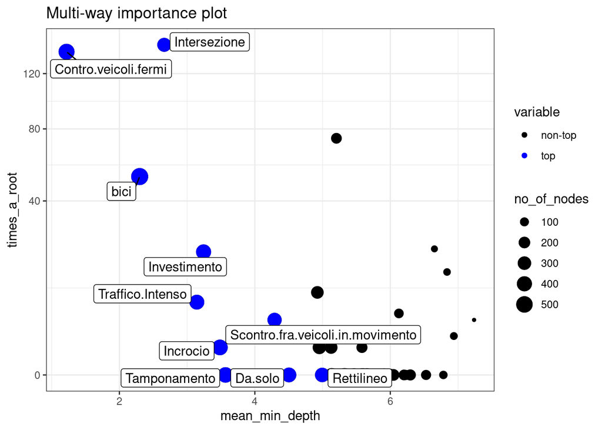

```r
importance_frame <- measure_importance(rf)

plot_multi_way_importance(importance_frame, size_measure='no_of_nodes')
```

Here it appears quite clear that `Contro.veicoli.fermi` and `Intersezione` are relevant variables since these are picked, on average, at low depths of the trees, often also as roots. Also `bici`, `Investimento` and `Traffico.Intenso` play their important role. In general, all the variables marked in blue seem to be relevant for the model to infer the amount of accidents.

To have even a better understanding, we can see at how the `MSE` increases if a specific variable is not chosen, and how its node impurity increases. In this case, the more a variable is on the right, the more it is relevant for predicting the number of accidents.

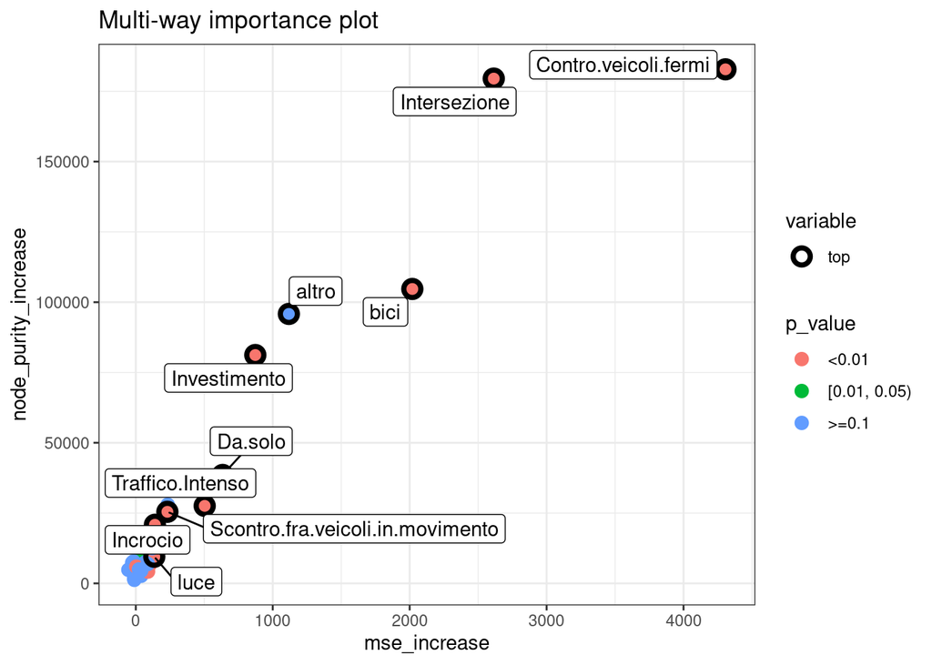

```r
plot_multi_way_importance(importance_frame, x_measure = "mse_increase", y_measure = "node_purity_increase", size_measure = "p_value", no_of_labels = 10)
```

This plot helps understanding which variables are crucial to minimize the error. According to it, `Contro.veicoli.fermi`, `Intersezione` and `bici` are relevant. Second to these we can also find `Investimento`.

Let’s try to predict the accidents through this model on new/unseen data:

```r
rf_preds <- predict(rf, newdata=new_df_test)

#RMSE
sqrt(sum((rf_preds - new_df_test$y)^2) / length(new_df_test$y))
```

```
## [1] 88.27707
```

With respect to the `pruned tree`, we are getting even better results (RMSE$=88$ vs. $100$). Let’s try to inspect the model through SHapely Additive exPlanations (SHAP). SHAP is a visualization tool that helps explaining black-box models allowing to compute the contribution of each feature to the predictions outputted by the model.

```r
par(mfrow=c(1, 3))

y_train <- new_df_train$y
X_train <- subset(new_df_train, select=-c(y))
y_test <- new_df_test$y
X_test <- subset(new_df_test, select=-c(y))

exp_rf <- DALEX::explain(model=rf,
                         data=X_train,
                         y=y_train)
```

```
## Preparation of a new explainer is initiated
##   -> model label       :  randomForest  (  default  )
##   -> data              :  76  rows  42  cols
##   -> target variable   :  76  values
##   -> predict function  :  yhat.randomForest  will be used (  default  )
##   -> predicted values  :  No value for predict function target column. (  default  )
##   -> model_info        :  package randomForest , ver. 4.7.1.1 , task regression (  default  )
##   -> predicted values  :  numerical, min =  0.0024 , mean =  83.91867 , max =  370.8958
##   -> residual function :  difference between y and yhat (  default  )
##   -> residuals         :  numerical, min =  -62.3107 , mean =  -2.313402 , max =  129.1042
##   A new explainer has been created!
```

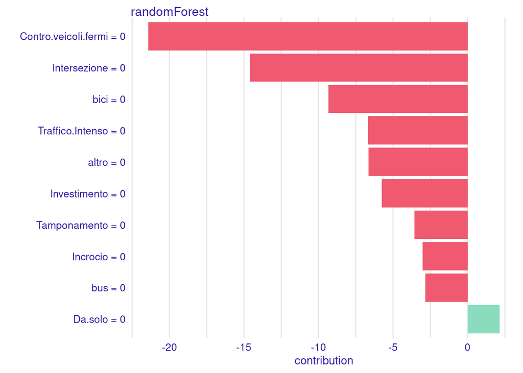

```r
cuts <- cut(y_test, breaks=3)

low = which(cuts == levels(cuts)[1])
mid = which(cuts == levels(cuts)[2])
high = which(cuts == levels(cuts)[3])

shap_preds_low <- predict_parts(explainer=exp_rf,
                            new_observation=X_test[low, ],
                            type='shap', name='Random Forest (low accidents)')

shap_preds_mid <- predict_parts(explainer=exp_rf,
                            new_observation=X_test[mid, ],
                            type='shap', name='Random Forest (mid accidents)')

shap_preds_high <- predict_parts(explainer=exp_rf,
                            new_observation=X_test[high, ],
                            type='shap', name='Random Forest (high accidents)')

plot(shap_preds_low, show_boxplots=F, titel='Random Forest (low accidents)')
```

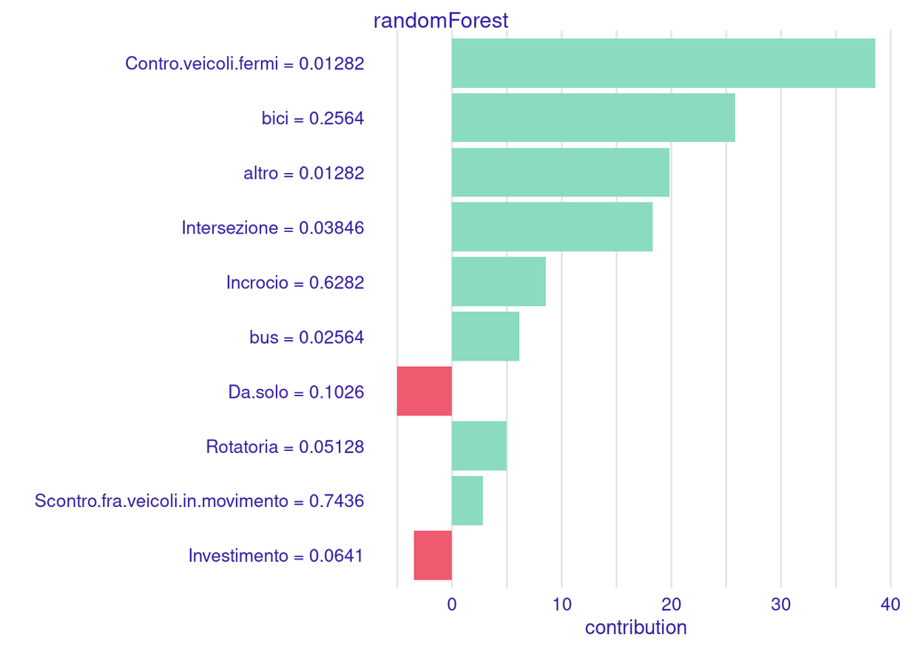

```r
plot(shap_preds_mid, show_boxplots=F, title='Random Forest (mid accidents)')
```

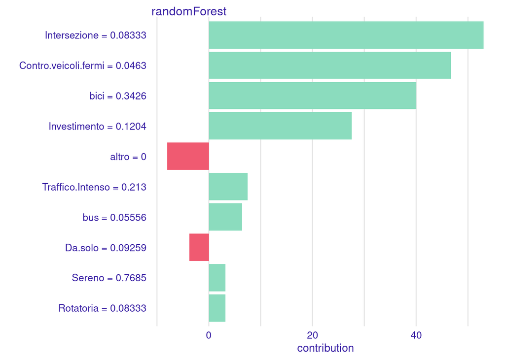

```r
plot(shap_preds_high, show_boxplots=F, title='Random Forest (high accidents)')
```

```r
par(mfrow=c(1, 1))
```

In general, it seems that the model relies on different values for pretty much the same variables while inferring the number of accidents. Of course the model cannot pre-determine in which scenario it is, but splitting the data this way allow to get a better idea about the exact proportions and their relevance.

At last, I am going to fit and tune different `Support Vector Machines` through different kernels (linear, radial, polynomial and sigmoid):

```r
costs <- seq(0.01, 0.3, 0.01)
# errors where thrown when keeping ghiacciato, Strada.pavimentata.dissestata and Altra.strada.
linear_svm <- tune(svm, y ~ ., data=new_df_test, kernel='linear',
                   ranges=list(cost=costs))
opt_cost_lin <- linear_svm$best.parameters$cost

opt_cost_lin
```

```
## [1] 0.01
```

```r
gammas = seq(0.05, 0.5, 0.05)
radial_svm <- tune(svm, y ~ ., data=new_df_test, kernel='radial',
                   ranges=list(cost=costs, gamma=gammas))

opt_cost_rad <- radial_svm$best.parameters$cost
opt_gamma_rad <- radial_svm$best.parameters$gamma

opt_cost_rad
```

```
## [1] 0.3
```

```r
opt_gamma_rad
```

```
## [1] 0.05
```

```r
degrees <- seq(1, 3, 1)
coef0 <- seq(0, 5, 1)

poly_svm <- tune(svm, y ~ ., data=new_df_test, kernel='polynomial',
                 ranges=list(cost=costs, gamma=gammas, degree=degrees, coef0=coef0))

opt_cost_poly <- poly_svm$best.parameters$cost
opt_gamma_poly <- poly_svm$best.parameters$gamma
opt_deg_poly <- poly_svm$best.parameters$degree
opt_coef_poly <- poly_svm$best.parameters$coef0

opt_cost_poly
```

```
## [1] 0.15
```

```r
opt_gamma_poly
```

```
## [1] 0.05
```

```r
opt_deg_poly
```

```
## [1] 1
```

```r
opt_coef_poly
```

```
## [1] 1
```

```r
sigm_svm <- tune(svm, y ~ ., data=new_df_test, kernel='sigmoid',
ranges=list(cost=costs, gamma=gammas, coef0=coef0))

opt_cost_sigm <- sigm_svm$best.parameters$cost
opt_gamma_sigm <- sigm_svm$best.parameters$gamma
opt_coef_sigm <- sigm_svm$best.parameters$coef0

opt_cost_sigm
```

```
## [1] 0.07
```

```r
opt_gamma_sigm
```

```
## [1] 0.15
```

```r
opt_coef_sigm
```

```
## [1] 0
```

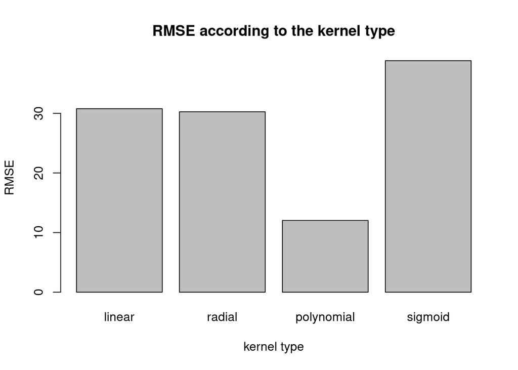

```r
lin_preds <- predict(linear_svm$best.model, newdata=new_df_test)
lin_rmse <- sqrt(sum((lin_preds - new_df_test$y)^2)/length(new_df_test))

rad_preds <- predict(radial_svm$best.model, newdata=new_df_test)
rad_rmse <- sqrt(sum((rad_preds - new_df_test$y)^2)/length(new_df_test))

poly_preds <- predict(poly_svm$best.model, newdata=new_df_test)
poly_rmse <- sqrt(sum(rad_preds - new_df_test$y)^2)/length(new_df_test)

sigm_preds <- predict(sigm_svm$best.model, newdata=new_df_test)
sigm_rmse <- sqrt(sum((sigm_preds - new_df_test$y)^2)/length(new_df_test))

barplot(names=c('linear', 'radial', 'polynomial', 'sigmoid'), c(lin_rmse, rad_rmse, poly_rmse, sigm_rmse), main='RMSE according to the kernel type', xlab='kernel type', ylab='RMSE')
```

```r
X_train <- subset(new_df_train, select=-c(y))
X_test <- subset(new_df_test, select=-c(y))
y_train <- new_df_train$y
y_test <- new_df_test$y

par(mfrow=c(3, 1))

exp_svm <- DALEX::explain(model=poly_svm$best.model,
                         data=X_train,
                         y=y_train)
```

```
## Preparation of a new explainer is initiated
##   -> model label       :  svm  (  default  )
##   -> data              :  76  rows  42  cols
##   -> target variable   :  76  values
##   -> predict function  :  yhat.svm  will be used (  default  )
##   -> predicted values  :  No value for predict function target column. (  default  )
##   -> model_info        :  package e1071 , ver. 1.7.12 , task regression (  default  )
##   -> predicted values  :  numerical, min =  -3.89382 , mean =  18.48911 , max =  64.03092
##   -> residual function :  difference between y and yhat (  default  )
##   -> residuals         :  numerical, min =  -16.8318 , mean =  63.11616 , max =  472.21
##   A new explainer has been created!
```

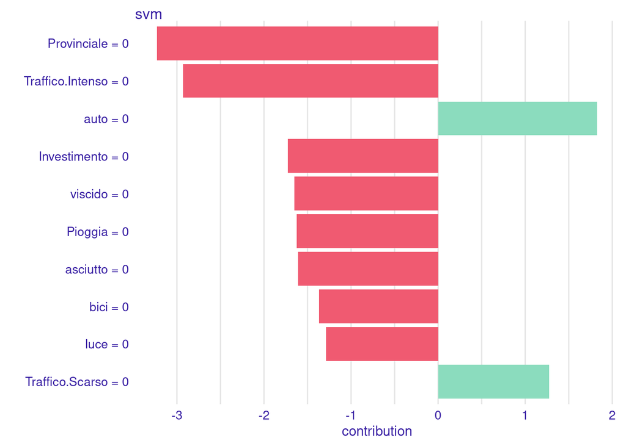

```r
shap_preds_low <- predict_parts(explainer=exp_svm,
                            new_observation=X_test[low, ],
                            type='shap')

shap_preds_mid <- predict_parts(explainer=exp_svm,
                            new_observation=X_test[mid, ],
                            type='shap')

shap_preds_high <- predict_parts(explainer=exp_svm,
                            new_observation=X_test[high, ],
                            type='shap')

plot(shap_preds_low, show_boxplots=F, main='SVM (low accidents)')
```

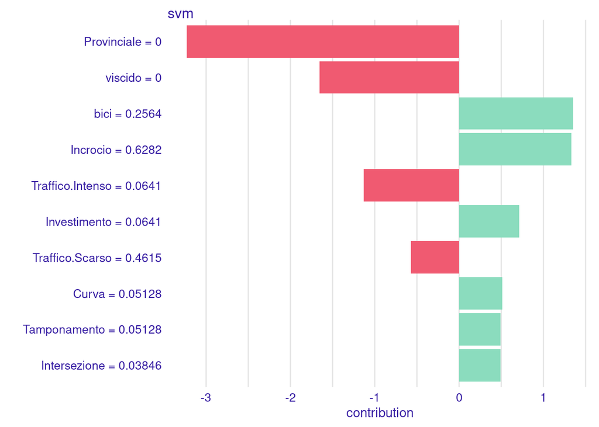

```r
plot(shap_preds_mid, show_boxplots=F, main='SVM (mid accidents)')
```

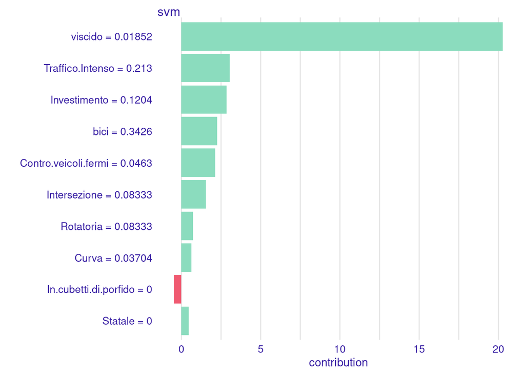

```r
plot(shap_preds_high, show_boxplots=F, main='SVM (high accidents)')
```

```r
par(mfrow=c(1, 1))
```

By splitting the data into `low`, `medium` and `high` number of accidents per area and looking at the shap for each of them, we can try to understand in which direction each variable pushes to and what is its impact in the prediction:

- `low`: In this scenario, the number of accidents is in the range $[0, 40]$. When the proportions of `Provinciale` and `Traffico.Intenso` are equal to zero, they are contributing negatively to the estimated number of accidents. When `auto` is zero, instead, the prediction of accidents is predicted as higher. Probably this is because the complete absence of accident that involved cars does not imply the complete absence of accidents. As I would expect, it is also possible to see that a proportion of `Traffico.Scarso` equal to zero contributes positively to the predicted number of accidents.
- `mid`: In this scenario, the number of accidents is in the range $[41, 81]$. Here `Provinciale` and `Viscido`, when zero, are contributing negatively to the estimate of the accidents. While `Bici` and `Incrocio` with their respective values $0.25$ and $0.62$ contribute positively to the estimates. Again, `Traffico.Intenso`, when at $0.06$ (still low) is contributing negatively to the predictions.
- `high`: In this scenario, the number of accidents is in the range $[82, 122]$. Here, `Viscido` seems to positively contribute to the predictions with values around $0.02$. After that, also `Traffico.Intenso` (when $=0.21$), `Investimento` (when $=0.12$) and `bici (when $=034$)` have a positive contribution to the predictions.

The models trained are not intended to be used for accident predictions in real scenarios though, not because they are performing poorly, but because, according to the nature of the data and its transformation, all the information required would be post-hoc (i.e., relative frequencies about the road segments involved, the type of accidents, …).

Some of the obtained results are still difficult to fully understand, despite the tools I have deployed to try understanding more the black-box models.

Nonetheless, implementing such models, capable of predicting the number of accidents in different areas of the city, is relevant to understand what variables are boosting (or lowering) the number of accidents.

As further improvements and possibilities to the current analyses, the data could be restructured in different ways and further enriched. In that case, it would be possible to implement other kind of models, that by including temporal and spatial information, for example could allow to effectively predict time and areas of future accidents. At this regard, the state of the art model is a `conv-lstm`, that showed pretty good capabilities in doing so.